# Assignment3_B_1_3

Sangamesh

26 September 2018

Reading data and making data into training and test data.

```
## [1] "head of training data"
```

```
##         Y1        X1        X2       X4
## 1 3.394395  3.442101 0.3286708 2.531468
## 2 2.783206 -1.913935 0.6070572 3.242823
## 3 5.332787 13.909262 0.5780297 2.631212
## 4 4.446709  3.046078 0.7084997 3.883400
## 5 5.543534  4.404784 0.2912077 4.316483
## 6 3.916571 -4.656940 0.1686171 4.267447
```

```
## [1] "head of testing data"
```

```
##            Y1         X1         X2        X4
## 10  2.9731911  4.4548862 0.03022539 1.8120901
## 20  5.9505248  9.6564968 0.36800421 3.7472017
## 30  1.3414354  1.2784499 0.48953224 1.3958129
## 40 -0.4241599  0.3036483 0.31690684 0.1267627
## 50  1.5125398 -0.6742719 0.94945253 2.1797810
## 60  0.9853793  3.2237377 0.85544483 0.9421779
```

Fitting data for linear regression model

```
##
## Call:
## lm(formula = Y1 ~ X1 + X2 + X4, data = trainData)
##
## Residuals:
##       Min        1Q    Median        3Q       Max
## -0.210075 -0.064858 -0.001555  0.069632  0.256274
##
## Coefficients:
##              Estimate Std. Error t value Pr(>|t|)
## (Intercept)  0.066625   0.027747   2.401   0.0185 *
## X1           0.199642   0.002292  87.102   <2e-16 ***
## X2          -1.051784   0.037636 -27.946   <2e-16 ***
## X4           1.160520   0.005730 202.526   <2e-16 ***
## ---
## Signif. codes:  0 '***' 0.001 '**' 0.01 '*' 0.05 '.' 0.1 ' ' 1
##
## Residual standard error: 0.09636 on 86 degrees of freedom
## Multiple R-squared:  0.9982, Adjusted R-squared:  0.9982
## F-statistic: 1.618e+04 on 3 and 86 DF,  p-value: < 2.2e-16
```

Several metrics useful for regression diagnostics : model.diag.metrics

| .rownames | Y1 | X1 | X2 | X4 | .fitted | .se.fit | .resid | .hat | .sigma | .cooksd | .std.resid |
| --- | --- | --- | --- | --- | --- | --- | --- | --- | --- | --- | --- |
| 1 | 3.394395 | 3.442101 | 0.3286708 | 2.531468 | 3.345943 | 0.01218612 | 0.048451238 | 0.01599341 | 0.09677984 | 1.044011e-03 | 0.50688686 |
| 2 | 2.783206 | -1.913935 | 0.6070572 | 3.242823 | 2.809391 | 0.01548262 | -0.026185236 | 0.02581662 | 0.09688201 | 5.022052e-04 | -0.27532224 |
| 3 | 5.332787 | 13.909262 | 0.5780297 | 2.631212 | 5.289115 | 0.02754449 | 0.043672460 | 0.08171086 | 0.09679860 | 4.976071e-03 | 0.47295856 |
| 4 | 4.446709 | 3.046078 | 0.7084997 | 3.883400 | 4.436326 | 0.01391149 | 0.010382841 | 0.02084288 | 0.09691805 | 6.310091e-05 | 0.10889180 |
| 5 | 5.543534 | 4.404784 | 0.2912077 | 4.316483 | 5.649084 | 0.01554590 | -0.105550514 | 0.02602808 | 0.09622802 | 8.230387e-03 | -1.10992158 |
| 6 | 3.916571 | -4.656940 | 0.1686171 | 4.267447 | 3.912012 | 0.02512162 | 0.004558603 | 0.06796816 | 0.09692338 | 4.377819e-05 | 0.04900287 |

Meta Data for model.diag.metrics Among the table columns, there are:

Y1: original values X1, X2: the observed values .fitted: the fitted values .resid: the residual errors

We can see the plot in residual and fitted plot here now:

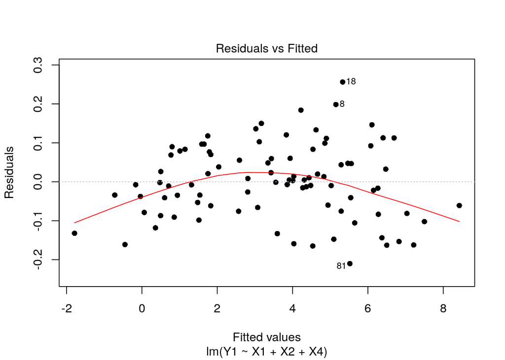

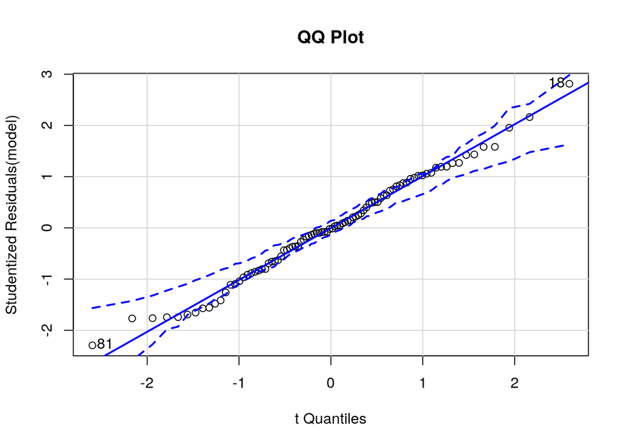

```
## 18 81
## 17 73
```

Check outliers:

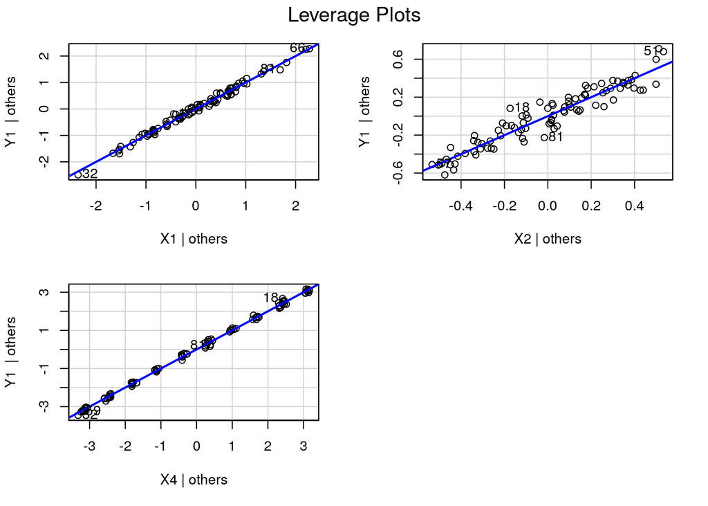

Check if errors are auto corelated

```
##
##  Durbin-Watson test
##
## data:  model
## DW = 1.5493, p-value = 0.01472
## alternative hypothesis: true autocorrelation is greater than 0
```

Influential Variables : Fiding influential data points is required. So let us look at variable plots:

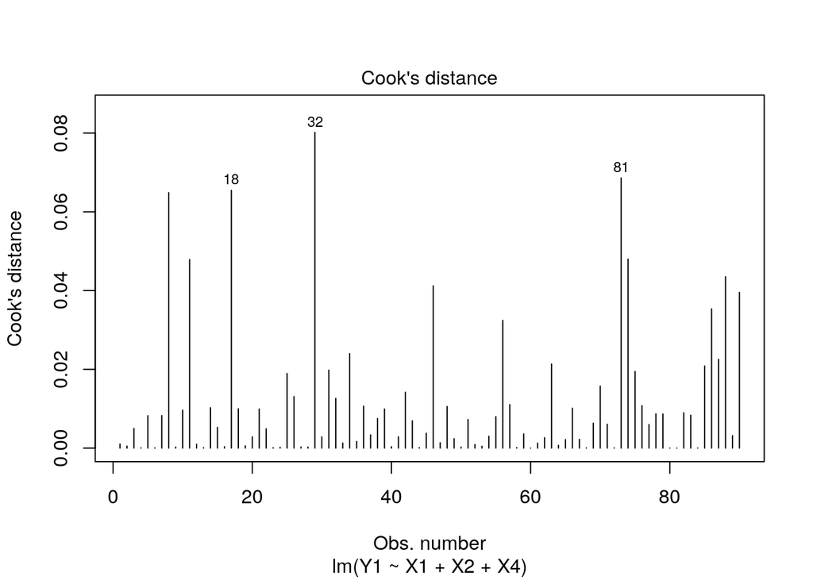

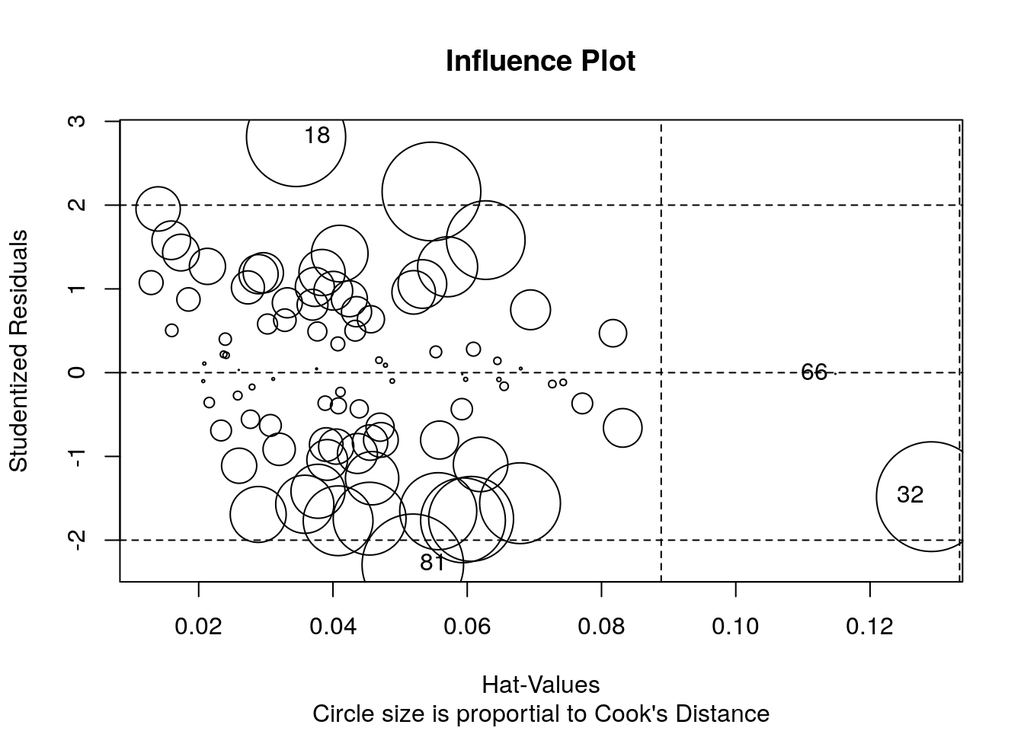

|  | StudRes | Hat | CookD |
| --- | --- | --- | --- |
| 18 | 2.81338698 | 0.03450780 | 6.546052e-02 |
| 32 | -1.48083549 | 0.12912835 | 8.017492e-02 |
| 66 | -0.01405232 | 0.11483649 | 6.479936e-06 |
| 81 | -2.29378874 | 0.05189565 | 6.859899e-02 |

Checking for Multi-collinearity:

```
##       X1       X2       X4
## 1.001778 1.002729 1.001661
```

```
##    X1    X2    X4
## FALSE FALSE FALSE
```

Non-constant Error Variance:

```
## Non-constant Variance Score Test
## Variance formula: ~ fitted.values
## Chisquare = 3.815566, Df = 1, p = 0.050778
```

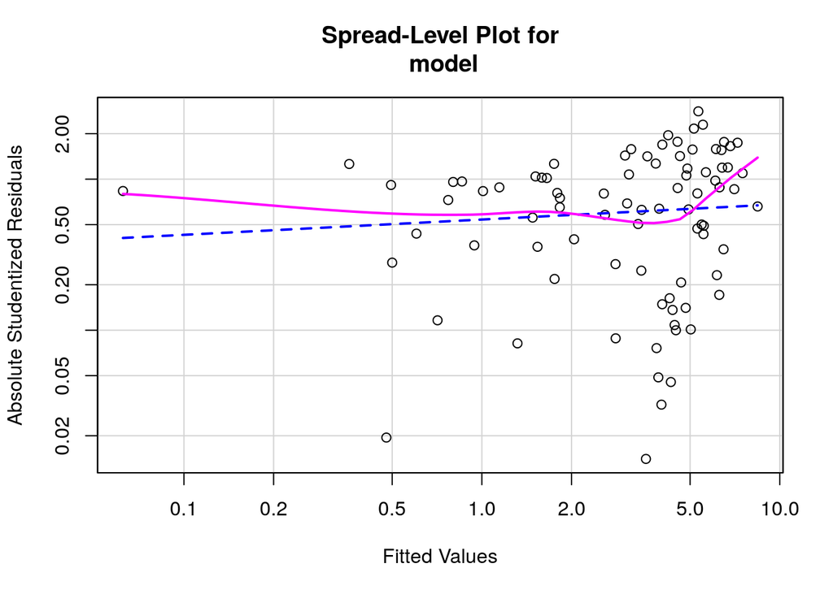

```
##
## Suggested power transformation:  0.898781
```

Nonlinearity test:

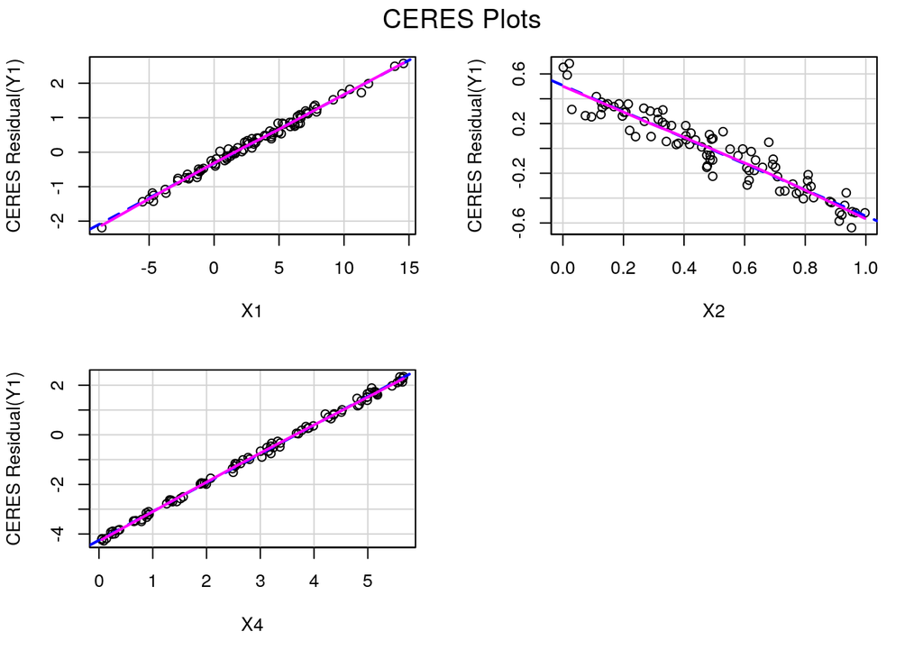

So all the factors are linear which is required.

Non-independence of Errors:

```
##  lag Autocorrelation D-W Statistic p-value
##    1        0.209135      1.549331   0.038
##  Alternative hypothesis: rho != 0
```